# climateStability Vignette: the Basics

Hannah Owens

2019-04-03

# Introduction

`climateStability` is a small set of `R`-based tools for generating climate stability estimates based on time slices of climate data.

# Calculating Stability

First, you give the `deviationThroughTime` function the location of a folder containing time slice data (as .ascii rasters) for a single variable, such as that produced by PaleoView (Fordham, *et al*. 2017, Ecography), and the time elapsed *between slices*. It will calculate the average standard deviation over time for each cell. Note that `deviationThroughTime` will use *all* the raster files in the given folder in order, so be careful that it only contains the files from which you want to calculate stability and that `R` loads the files in the correct order.

The function accomodates datasets with even temporal intervals, as well as uneven intervals. First, here is an example with a dataset that has time slices every 1,000 years.

```r
# deviationThroughTime using even time slices
precipDeviation <- deviationThroughTime(variableDirectory = "../../ClimateStabilityManuscript/precipfiles/",
                                        timeSlicePeriod = 1000);
temperatureDeviation <- deviationThroughTime(variableDirectory = "../../ClimateStabilityManuscript/tempfiles/",
                                             timeSlicePeriod = 1000);
```

Here is an example with a dataset that has uneven time slices for 1kybp to 5 kybp, 10kybp, 15kybp, and 21kybp. In this case, `timeSlicePeriod` can take a vector specifying the time elapsed between slices. NOTE: make sure the vector is in the *same order* as your time slices. There should be one fewer `timeSlicePeriod` item than the numer of climate slice files.

```r
# deviationThroughTime using uneven time slices
unevenPrecipDeviation <- deviationThroughTime(variableDirectory = "../../ClimateStabilityManuscript/precipfilesThinned/",
                                              timeSlicePeriod = c(1000, 1000, 1000, 1000, 5000, 5000, 6000));
unevenTemperatureDeviation <- deviationThroughTime(variableDirectory = "../../ClimateStabilityManuscript/tempfilesThinned/",
                                                   timeSlicePeriod = c(1000, 1000, 1000, 1000, 5000, 5000, 6000));
```

Let’s load them into the `R` environment.

```r
#Using deviationThroughTime
data(precipDeviation, package = "climateStability");
data(temperatureDeviation, package = "climateStability");
```

```r
precipInvDev <- 1/precipDeviation;
precipStability <- rescale0to1(precipInvDev);

tempInvDev <- 1/temperatureDeviation;
tempStability <- rescale0to1(tempInvDev);
```

Finally, to estimate climatic stability, multiply the individual climate variable stability estimates together.

```r
climateStability <- rescale0to1(precipStability * tempStability)
```

# Plots showing stability

These data can be visualized either as rasters or as line graphs showing the relationship between latitude and stability (or however you want to display them–I won’t tell you how to live your life).

## Stability rasters

This is what climate the stability rasters look like.

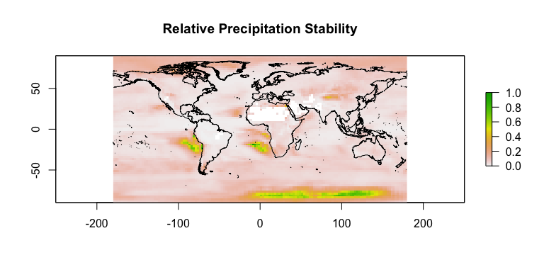

```r
plot(precipStability, main = "Relative Precipitation Stability");
plot(gshhs, add = T)
```

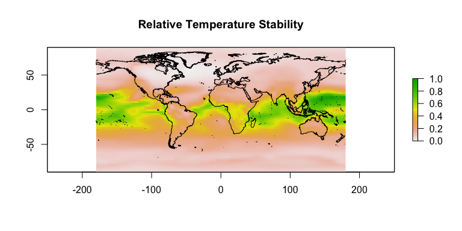

```r
plot(tempStability, main = "Relative Temperature Stability");
plot(gshhs, add = T)
```

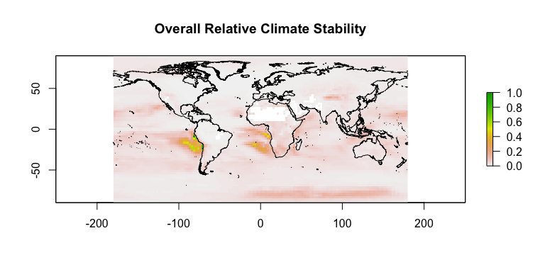

```r
plot(climateStability, main = "Overall Relative Climate Stability");
plot(gshhs, add = T)
```

## Stability line graphs

The `climateStability` package also comes with a useful tool for calculating mean stability per line of latitude, `latitudinalMean`. This can then be used to plot climate stability for a given variable as a response to latitude.

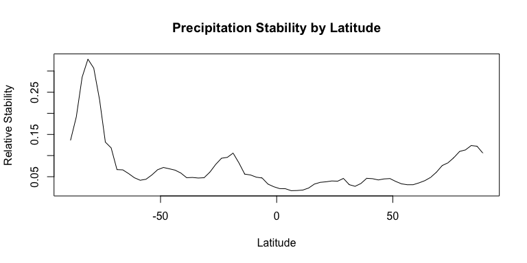

```r
#Calculate mean values at rasters
plot(latitudinalMean(precipStability), main = "Precipitation Stability by Latitude",
     ylab = "Relative Stability", type = "l");
```

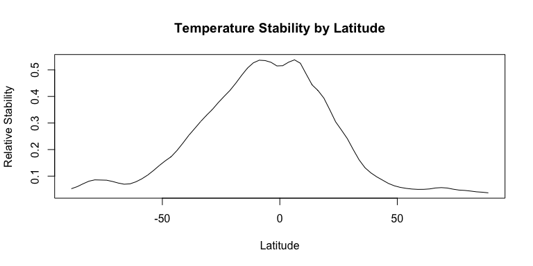

```r
plot(latitudinalMean(tempStability), main = "Temperature Stability by Latitude",
     ylab = "Relative Stability", type = "l");
```

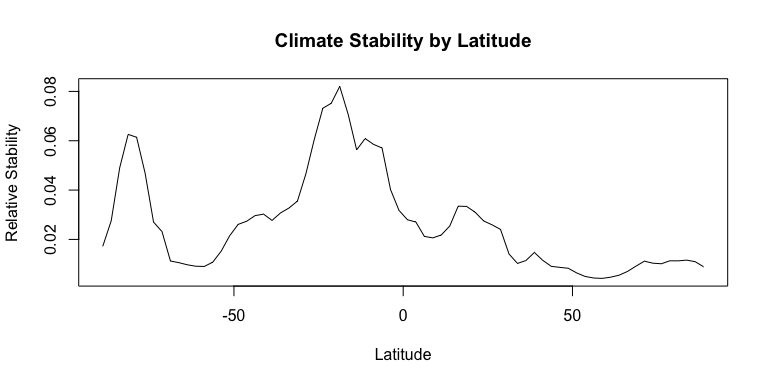

```r
plot(latitudinalMean(climateStability), main = "Climate Stability by Latitude",
     ylab = "Relative Stability", type = "l");
```

Additionally, `climateStability` can calculate mean stability versus the absolute value of the latitudinal mean using the function `absLatitudinalMean`.

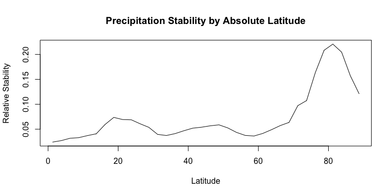

```r
#Calculate mean values at rasters
plot(absLatitudinalMean(precipStability), main = "Precipitation Stability by Absolute Latitude",
     ylab = "Relative Stability", type = "l");
```

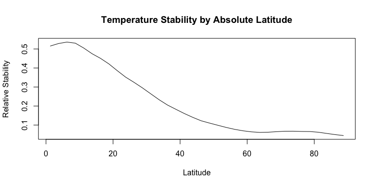

```r
plot(absLatitudinalMean(tempStability), main = "Temperature Stability by Absolute Latitude",
     ylab = "Relative Stability", type = "l");
```

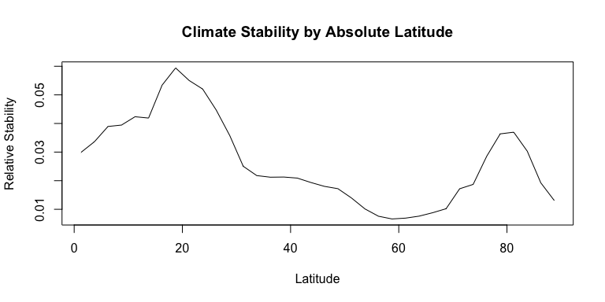

```r
plot(absLatitudinalMean(climateStability), main = "Climate Stability by Absolute Latitude",
     ylab = "Relative Stability", type = "l");
```